# 03.1-BLAST

Lara Breitkreutz

April 21, 2025

```
## current date and time is  April 21, 2025 10:11:19
```

## 0.1 Introduction

I will be re-creating **01-blast.Rmd** to explore some of the functionality in markdown. In this document, I will be taking an unknown multi-fasta file and annotating it using NCBI Blast software.

**1. What is a multi-fasta file? Glad you asked!**

- a plain text file used in bioinformatics to store multiple (thousands) of biological sequences in a single place.
- later, we will explore what these fasta files contain.

# 1 Database creation

## 1.1 Download blast software

I am going download the blast software, which I will be using to compare our unknown sequences to known sequences.

```bash
cd /home/jovyan/applications
curl -O https://ftp.ncbi.nlm.nih.gov/blast/executables/blast+/LATEST/ncbi-blast-2.16.0+-x64-linux.tar.gz
tar -xf ncbi-blast-2.16.0+-x64-linux.tar.gz
```

Let’s check what we’ve just downloaded…

```bash
pwd
ncbi-blast-2.16.0+/bin/blastx -h
```

[output not shown]

-h displays the help message associated with the blastx document. This help message provides a list of available command-line options, their descriptions, and instructions for using blastx.

## 1.2 Obtain the fasta file (UniProt/Swiss-Prot)

```bash
cd data/blast_data
curl -O https://ftp.uniprot.org/pub/databases/uniprot/current_release/knowledgebase/complete/uniprot_sprot.fasta.gz
mv uniprot_sprot.fasta.gz uniprot_sprot_r2025_04_03.fasta.gz
gunzip -k uniprot_sprot_r2025_04_03.fasta.gz
```

What files did we just download?

```bash
ls data/blast_data
```

[output not shown]

```bash
./ncbi-blast-2.16.0+/bin/makeblastdb \
-in data/blast_data/uniprot_sprot_r2025_04_03.fasta \
-dbtype prot \
-out data/blast_data/uniprot_sprot_r2025_04_03
```

## 1.3 Getting the query fasta file

```bash
curl https://eagle.fish.washington.edu/cnidarian/Ab_4denovo_CLC6_a.fa \
-k \
> ./data/blast_data/Ab_4denovo_CLC6_a.fa
```

## 1.4 Exploring the fasta file

```bash
head ./data/blast_data/Ab_4denovo_CLC6_a.fa
```

[output not shown]

Okay, we are finally looking at our sequence reads!

A fasta file can be recognized by a couple key characteristics:

- A header line that starts with a “>” character, followed by a sequence identifier and, likely, an optional description.
- Lines that contain the sequence (or sequences), represented by the nucleotide letters we are all familiar with (A, G, C, and T).

**How many sequences are there?**

```bash
#echo "How many sequences are there?"
grep -c ">" ./data/blast_data/Ab_4denovo_CLC6_a.fa
```

[output not shown]

**What is the frequency distribution of our sequence lengths?**

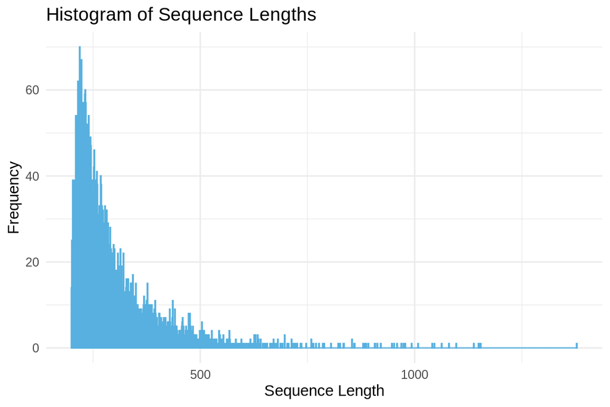

```r
# Read FASTA file
fasta_file <- "./data/blast_data/Ab_4denovo_CLC6_a.fa"  # Replace with the name of your FASTA file
sequences <- readDNAStringSet(fasta_file)

# Calculate sequence lengths
sequence_lengths <- width(sequences)

# Create a data frame
sequence_lengths_df <- data.frame(Length = sequence_lengths)

# Plot histogram using ggplot2
ggplot(sequence_lengths_df, aes(x = Length)) +
  geom_histogram(binwidth = 1, color = "#57b0df", alpha = 0.75) +
  labs(title = "Histogram of Sequence Lengths",
       x = "Sequence Length",
       y = "Frequency") +
  theme_minimal()
```

**What is the base composition of our sequences?**

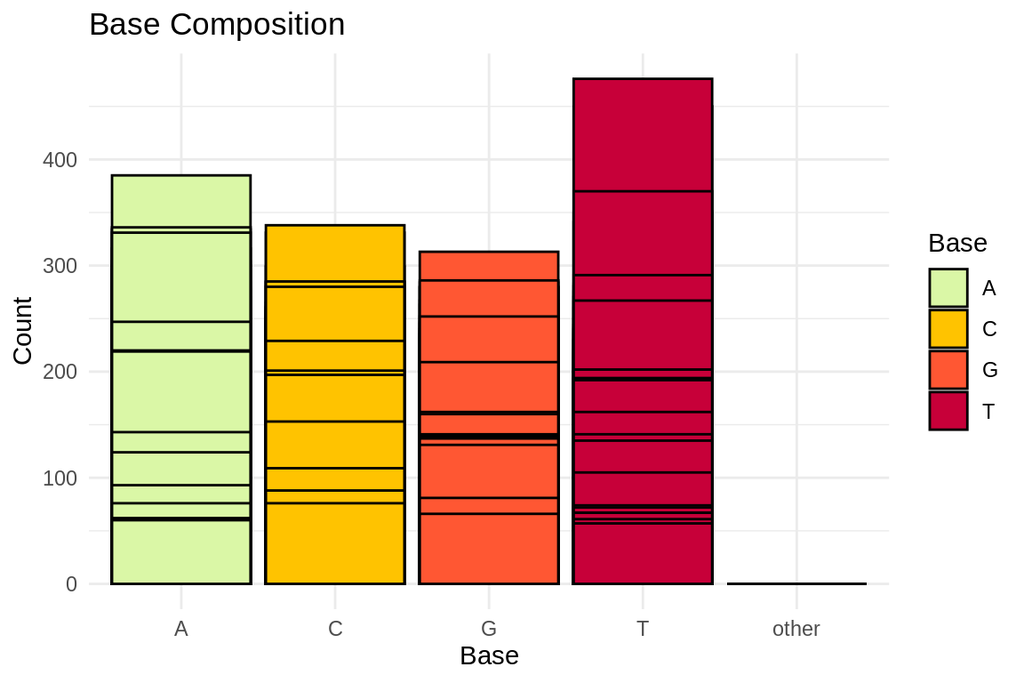

```r
# Read FASTA file
fasta_file <- "./data/blast_data/Ab_4denovo_CLC6_a.fa"
sequences <- readDNAStringSet(fasta_file)

# Calculate base composition
base_composition <- alphabetFrequency(sequences, baseOnly = TRUE)

# Convert to data frame and reshape for ggplot2
base_composition_df <- as.data.frame(base_composition)
base_composition_df$ID <- rownames(base_composition_df)
base_composition_melted <- reshape2::melt(base_composition_df, id.vars = "ID", variable.name = "Base", value.name = "Count")

# Plot base composition bar chart using ggplot2
ggplot(base_composition_melted, aes(x = Base, y = Count, fill = Base)) +
  geom_bar(stat = "identity", position = "dodge", color = "black") +
  labs(title = "Base Composition",
       x = "Base",
       y = "Count") +
  theme_minimal() +
  scale_fill_manual(values = c("A" = "#DAF7A6", "C" = "#FFC300", "G" = "#FF5733", "T" = "#C70039"))
```

# 2 Run blast

```bash
/home/shared/ncbi-blast-2.15.0+/bin/blastx \
-query ../data/Ab_4denovo_CLC6_a.fa \
-db ../output/01-blast/blastdb/uniprot_sprot_r2025_04_03 \
-out ../output/01-blast/Ab_4-uniprot_blastx.tab \
-evalue 1E-20 \
-num_threads 20 \
-max_target_seqs 1 \
-outfmt 6
```

```bash
head -2 output/Ab_4-uniprot_blastx.tab
```

```
## solid0078_20110412_FRAG_BC_WHITE_WHITE_F3_QV_SE_trimmed_contig_3 sp|O42248|GBLP_DANRE    82.456  171 30  0   1   513 35  205 2.83e-103   301
## solid0078_20110412_FRAG_BC_WHITE_WHITE_F3_QV_SE_trimmed_contig_5 sp|Q08013|SSRG_RAT  75.385  65  16  0   3   197 121 185 1.41e-28    104
```

```bash
echo "Number of lines in output"
wc -l output/Ab_4-uniprot_blastx.tab
```

```
## Number of lines in output
## 765 output/Ab_4-uniprot_blastx.tab
```

# 3 Joining Blast table with annoations.

## 3.1 Prepping Blast table for easy join

```bash
tr '|' '\t' < output/Ab_4-uniprot_blastx.tab \
> output/Ab_4-uniprot_blastx_sep.tab

head -1 output/Ab_4-uniprot_blastx_sep.tab
```

```
## solid0078_20110412_FRAG_BC_WHITE_WHITE_F3_QV_SE_trimmed_contig_3 sp  O42248  GBLP_DANRE  82.456  171 30  0   1   513 35  205 2.83e-103   301
```

## 3.2 Could do some cool stuff in R here reading in table

```r
bltabl <- read.csv("output/Ab_4-uniprot_blastx_sep.tab", sep = '\t', header = FALSE)

spgo <- read.csv("https://gannet.fish.washington.edu/seashell/snaps/uniprot_table_r2023_01.tab", sep = '\t', header = TRUE)
```

```r
datatable(head(bltabl), options = list(scrollX = TRUE, scrollY = "400px", scrollCollapse = TRUE, paging = FALSE))
```

|  | V1 | V2 | V3 | V4 | V5 | V6 | V7 | V8 | V9 | V10 | V11 | V12 | V13 | V14 |
| --- | --- | --- | --- | --- | --- | --- | --- | --- | --- | --- | --- | --- | --- | --- |
| 1 | solid0078_20110412_FRAG_BC_WHITE_WHITE_F3_QV_SE_trimmed_contig_3 | sp | O42248 | GBLP_DANRE | 82.456 | 171 | 30 | 0 | 1 | 513 | 35 | 205 | 2.83e-103 | 301 |
| 2 | solid0078_20110412_FRAG_BC_WHITE_WHITE_F3_QV_SE_trimmed_contig_5 | sp | Q08013 | SSRG_RAT | 75.385 | 65 | 16 | 0 | 3 | 197 | 121 | 185 | 1.41e-28 | 104 |
| 3 | solid0078_20110412_FRAG_BC_WHITE_WHITE_F3_QV_SE_trimmed_contig_6 | sp | P12234 | S25A3_BOVIN | 76.623 | 77 | 18 | 0 | 2 | 232 | 286 | 362 | 7.35e-24 | 98.6 |
| 4 | solid0078_20110412_FRAG_BC_WHITE_WHITE_F3_QV_SE_trimmed_contig_9 | sp | Q41629 | ADT1_WHEAT | 82.258 | 62 | 11 | 0 | 3 | 188 | 170 | 231 | 6.12e-28 | 104 |
| 5 | solid0078_20110412_FRAG_BC_WHITE_WHITE_F3_QV_SE_trimmed_contig_13 | sp | Q32NG4 | GALD1_XENLA | 54.444 | 90 | 40 | 1 | 1 | 270 | 140 | 228 | 1.52e-28 | 106 |
| 6 | solid0078_20110412_FRAG_BC_WHITE_WHITE_F3_QV_SE_trimmed_contig_23 | sp | Q9GNE2 | RL23_AEDAE | 97.222 | 72 | 2 | 0 | 67 | 282 | 14 | 85 | 6.86e-44 | 142 |

```r
datatable(head(spgo), options = list(scrollX = TRUE, scrollY = "400px", scrollCollapse = TRUE, paging = FALSE))
```

|  | Entry | Reviewed | Entry.Name | Protein.names | Gene.Names | Organism | Length | Gene.Ontology..molecular.function. | Gene.Ontology..GO. | Gene.Ontology..biological.process. | Gene.Ontology..cellular.component. | Gene.Ontology.IDs | Interacts.with | EC.number | Reactome | UniPathway | InterPro |
| --- | --- | --- | --- | --- | --- | --- | --- | --- | --- | --- | --- | --- | --- | --- | --- | --- | --- |
| 1 | A0A023I7E1 | reviewed | ENG1_RHIMI | Glucan endo-1,3-beta-D-glucosidase 1 (Endo-1,3-beta-glucanase 1) (EC 3.2.1.39) (Laminarinase) (RmLam81A) | ENG1 LAM81A | Rhizomucor miehei | 796 | glucan endo-1,3-beta-D-glucosidase activity [GO:0042973]; glucan endo-1,3-beta-glucanase activity, C-3 substituted reducing group [GO:0052861]; glucan endo-1,4-beta-glucanase activity, C-3 substituted… | extracellular region [GO:0005576]; glucan endo-1,3-beta-D-glucosidase activity [GO:0042973]; glucan endo-1,3-beta-glucanase activity, C-3 substituted reducing group [GO:0052861]; glucan endo-1,4-beta-… | cell wall organization [GO:0071555]; polysaccharide catabolic process [GO:0000272] | extracellular region [GO:0005576] | GO:0000272; GO:0005576; GO:0042973; GO:0052861; GO:0052862; GO:0071555 |  | 3.2.1.39 |  |  | IPR005200;IPR040720;IPR040451; |
| 2 | A0A024B7W1 | reviewed | POLG_ZIKVF | Genome polyprotein [Cleaved into: Capsid protein C (Capsid protein) (Core protein); Protein prM (Precursor membrane protein); Peptide pr (Peptide precursor); Small envelope protein M (Matrix protein);… |  | Zika virus (isolate ZIKV/Human/French Polynesia/10087PF/2013) (ZIKV) | 3423 | 4 iron, 4 sulfur cluster binding [GO:0051539]; ATP binding [GO:0005524]; ATP hydrolysis activity [GO:0016887]; double-stranded RNA binding [GO:0003725]; exogenous protein binding [GO:0140272]; GTP bin… | extracellular region [GO:0005576]; host cell endoplasmic reticulum membrane [GO:0044167]; host cell nucleus [GO:0042025]; host cell perinuclear region of cytoplasm [GO:0044220]; membrane [GO:0016020];… | clathrin-dependent endocytosis of virus by host cell [GO:0075512]; fusion of virus membrane with host endosome membrane [GO:0039654]; induction by virus of host autophagy [GO:0039520]; proteolysis [GO… | extracellular region [GO:0005576]; host cell endoplasmic reticulum membrane [GO:0044167]; host cell nucleus [GO:0042025]; host cell perinuclear region of cytoplasm [GO:0044220]; membrane [GO:0016020];… | GO:0003724; GO:0003725; GO:0003968; GO:0004252; GO:0004482; GO:0004483; GO:0005198; GO:0005524; GO:0005525; GO:0005576; GO:0006508; GO:0016020; GO:0016887; GO:0019028; GO:0019031; GO:0019062; GO:00395… |  | 2.1.1.56; 2.1.1.57; 2.7.7.48; 3.4.21.91; 3.6.1.15; 3.6.4.13 |  |  | IPR011492;IPR043502;IPR000069;IPR038302;IPR013755;IPR001122;IPR037172;IPR027287;IPR026470;IPR038345;IPR001157;IPR000752;IPR000487;IPR000404;IPR001528;IPR046811;IPR002535;IPR038688;IPR000336;IPR001850;… |
| 3 | A0A024SC78 | reviewed | CUTI1_HYPJR | Cutinase (EC 3.1.1.74) | M419DRAFT_76732 | Hypocrea jecorina (strain ATCC 56765 / BCRC 32924 / NRRL 11460 / Rut C-30) (Trichoderma reesei) | 248 | cutinase activity [GO:0050525] | extracellular region [GO:0005576]; cutinase activity [GO:0050525] |  | extracellular region [GO:0005576] | GO:0005576; GO:0050525 |  | 3.1.1.74 |  |  | IPR029058;IPR000675;IPR043580;IPR043579;IPR011150; |
| 4 | A0A024SH76 | reviewed | GUX2_HYPJR | Exoglucanase 2 (EC 3.2.1.91) (1,4-beta-cellobiohydrolase) (Cellobiohydrolase 6A) (Cel6A) (Exocellobiohydrolase II) (CBHII) (Exoglucanase II) | cbh2 M419DRAFT_122470 | Hypocrea jecorina (strain ATCC 56765 / BCRC 32924 / NRRL 11460 / Rut C-30) (Trichoderma reesei) | 471 | cellulose 1,4-beta-cellobiosidase activity [GO:0016162]; cellulose binding [GO:0030248] | extracellular region [GO:0005576]; cellulose 1,4-beta-cellobiosidase activity [GO:0016162]; cellulose binding [GO:0030248]; cellulose catabolic process [GO:0030245] | cellulose catabolic process [GO:0030245] | extracellular region [GO:0005576] | GO:0005576; GO:0016162; GO:0030245; GO:0030248 |  | 3.2.1.91 |  |  | IPR016288;IPR036434;IPR035971;IPR000254;IPR001524; |
| 5 | A0A026W182 | reviewed | ORCO_OOCBI | Odorant receptor coreceptor | Orco X777_12371 | Ooceraea biroi (Clonal raider ant) (Cerapachys biroi) | 478 | odorant binding [GO:0005549]; olfactory receptor activity [GO:0004984] | plasma membrane [GO:0005886]; odorant binding [GO:0005549]; olfactory receptor activity [GO:0004984]; antennal development [GO:0007469]; detection of chemical stimulus involved in sensory perception o… | antennal development [GO:0007469]; detection of chemical stimulus involved in sensory perception of smell [GO:0050911]; detection of pheromone [GO:0043695]; olfactory behavior [GO:0042048]; response t… | plasma membrane [GO:0005886] | GO:0004984; GO:0005549; GO:0005886; GO:0007165; GO:0007469; GO:0019236; GO:0035176; GO:0042048; GO:0043695; GO:0050911 |  |  |  |  | IPR004117; |
| 6 | A0A044RE18 | reviewed | BLI_ONCVO | Endoprotease bli (EC 3.4.21.75) (Blisterase) | Bli | Onchocerca volvulus | 693 | metal ion binding [GO:0046872]; serine-type endopeptidase activity [GO:0004252] | extracellular region [GO:0005576]; metal ion binding [GO:0046872]; serine-type endopeptidase activity [GO:0004252]; dibasic protein processing [GO:0090472]; zymogen activation [GO:0031638] | dibasic protein processing [GO:0090472]; zymogen activation [GO:0031638] | extracellular region [GO:0005576] | GO:0004252; GO:0005576; GO:0031638; GO:0046872; GO:0090472 |  | 3.4.21.75 |  |  | IPR008979;IPR034182;IPR002884;IPR000209;IPR036852;IPR023827;IPR022398;IPR023828;IPR015500;IPR032815;IPR038466; |

```r
datatable(
  left_join(bltabl, spgo,  by = c("V3" = "Entry")) %>%
  select(V1, V3, V13, Protein.names, Organism, Gene.Ontology..biological.process., Gene.Ontology.IDs) %>% mutate(V1 = str_replace_all(V1,
            pattern = "solid0078_20110412_FRAG_BC_WHITE_WHITE_F3_QV_SE_trimmed", replacement = "Ab"))
)
```

|  | V1 | V3 | V13 | Protein.names | Organism | Gene.Ontology..biological.process. | Gene.Ontology.IDs |
| --- | --- | --- | --- | --- | --- | --- | --- |
| 1 | Ab_contig_3 | O42248 | 2.83e-103 | Guanine nucleotide-binding protein subunit beta-2-like 1 (Receptor of activated protein kinase C) (RACK) | Danio rerio (Zebrafish) (Brachydanio rerio) | angiogenesis [GO:0001525]; convergent extension involved in gastrulation [GO:0060027]; negative regulation of Wnt signaling pathway [GO:0030178]; positive regulation of gastrulation [GO:2000543]; posi… | GO:0001525; GO:0001934; GO:0005080; GO:0005634; GO:0005737; GO:0005829; GO:0005840; GO:0030178; GO:0032880; GO:0043022; GO:0045182; GO:0051302; GO:0060027; GO:0072344; GO:1990904; GO:2000114; GO:20005… |
| 2 | Ab_contig_5 | Q08013 | 1.41e-28 | Translocon-associated protein subunit gamma (TRAP-gamma) (Signal sequence receptor subunit gamma) (SSR-gamma) | Rattus norvegicus (Rat) | SRP-dependent cotranslational protein targeting to membrane [GO:0006614] | GO:0005783; GO:0005784; GO:0006614 |
| 3 | Ab_contig_6 | P12234 | 7.35e-24 | Phosphate carrier protein, mitochondrial (Phosphate transport protein) (PTP) (Solute carrier family 25 member 3) | Bos taurus (Bovine) | mitochondrial phosphate ion transmembrane transport [GO:1990547]; phosphate ion transmembrane transport [GO:0035435] | GO:0005315; GO:0005739; GO:0005743; GO:0015293; GO:0035435; GO:0044877; GO:1990547 |
| 4 | Ab_contig_9 | Q41629 | 6.12e-28 | ADP,ATP carrier protein 1, mitochondrial (ADP/ATP translocase 1) (Adenine nucleotide translocator 1) (ANT 1) | Triticum aestivum (Wheat) | mitochondrial ADP transmembrane transport [GO:0140021]; mitochondrial ATP transmembrane transport [GO:1990544] | GO:0005471; GO:0005743; GO:0140021; GO:1990544 |
| 5 | Ab_contig_13 | Q32NG4 | 1.52e-28 | Glutamine amidotransferase-like class 1 domain-containing protein 1 (Parkinson disease 7 domain-containing protein 1) | Xenopus laevis (African clawed frog) |  | GO:0005576 |
| 6 | Ab_contig_23 | Q9GNE2 | 6.86e-44 | 60S ribosomal protein L23 (AeRpL17A) (L17A) | Aedes aegypti (Yellowfever mosquito) (Culex aegypti) | translation [GO:0006412] | GO:0003735; GO:0005840; GO:0006412; GO:1990904 |
| 7 | Ab_contig_31 | B3EWZ9 | 1.81e-44 | Hephaestin-like protein (EC 1.-.-.-) | Acropora millepora (Staghorn coral) (Heteropora millepora) | copper ion transport [GO:0006825] | GO:0005507; GO:0005576; GO:0006825; GO:0016020; GO:0016491 |
| 8 | Ab_contig_31 | B3EWZ9 | 9.25e-30 | Hephaestin-like protein (EC 1.-.-.-) | Acropora millepora (Staghorn coral) (Heteropora millepora) | copper ion transport [GO:0006825] | GO:0005507; GO:0005576; GO:0006825; GO:0016020; GO:0016491 |
| 9 | Ab_contig_31 | B3EWZ9 | 1.2e-27 | Hephaestin-like protein (EC 1.-.-.-) | Acropora millepora (Staghorn coral) (Heteropora millepora) | copper ion transport [GO:0006825] | GO:0005507; GO:0005576; GO:0006825; GO:0016020; GO:0016491 |
| 10 | Ab_contig_32 | Q641Y2 | 6.47e-72 | NADH dehydrogenase [ubiquinone] iron-sulfur protein 2, mitochondrial (EC 7.1.1.2) (Complex I-49kD) (CI-49kD) (NADH-ubiquinone oxidoreductase 49 kDa subunit) | Rattus norvegicus (Rat) | cellular response to oxygen levels [GO:0071453]; gliogenesis [GO:0042063]; mitochondrial ATP synthesis coupled electron transport [GO:0042775]; mitochondrial electron transport, NADH to ubiquinone [GO… | GO:0005654; GO:0005743; GO:0005747; GO:0006120; GO:0006979; GO:0008137; GO:0019826; GO:0022008; GO:0031625; GO:0032981; GO:0042063; GO:0042775; GO:0046872; GO:0048038; GO:0051287; GO:0051539; GO:00613… |

[output cut: 755 more lines]

```r
annot_tab <-
  left_join(bltabl, spgo,  by = c("V3" = "Entry")) %>%
  select(V1, V3, V13, Protein.names, Organism, Gene.Ontology..biological.process., Gene.Ontology.IDs) %>% mutate(V1 = str_replace_all(V1,
            pattern = "solid0078_20110412_FRAG_BC_WHITE_WHITE_F3_QV_SE_trimmed", replacement = "Ab"))
```

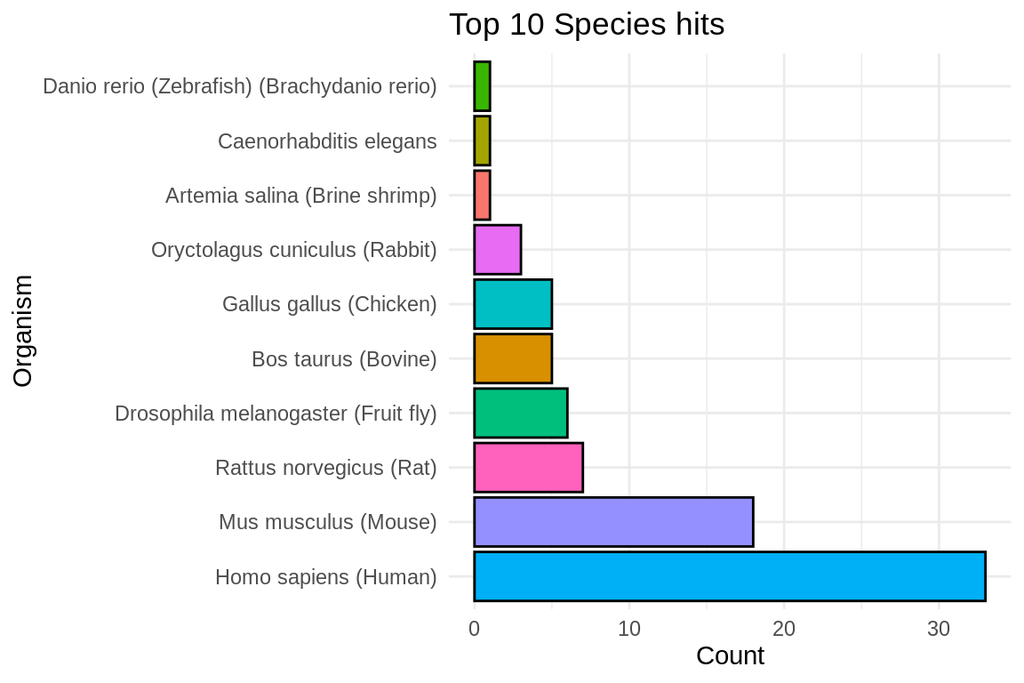

```r
# Read dataset
dataset <- read.csv("blast_annot_go.tab", sep = '\t')  # Replace with the path to your dataset

# Select the column of interest
column_name <- "Organism"  # Replace with the name of the column of interest
column_data <- dataset[[column_name]]

# Count the occurrences of the strings in the column
string_counts <- table(column_data)

# Convert to a data frame, sort by count, and select the top 10
string_counts_df <- as.data.frame(string_counts)
colnames(string_counts_df) <- c("String", "Count")
string_counts_df <- string_counts_df[order(string_counts_df$Count, decreasing = TRUE), ]
top_10_strings <- head(string_counts_df, n = 10)

# Plot the top 10 most common strings using ggplot2
ggplot(top_10_strings, aes(x = reorder(String, -Count), y = Count, fill = String)) +
  geom_bar(stat = "identity", position = "dodge", color = "black") +
  labs(title = "Top 10 Species hits",
       x = column_name,
       y = "Count") +
  theme_minimal() +
  theme(legend.position = "none") +
  coord_flip()
```

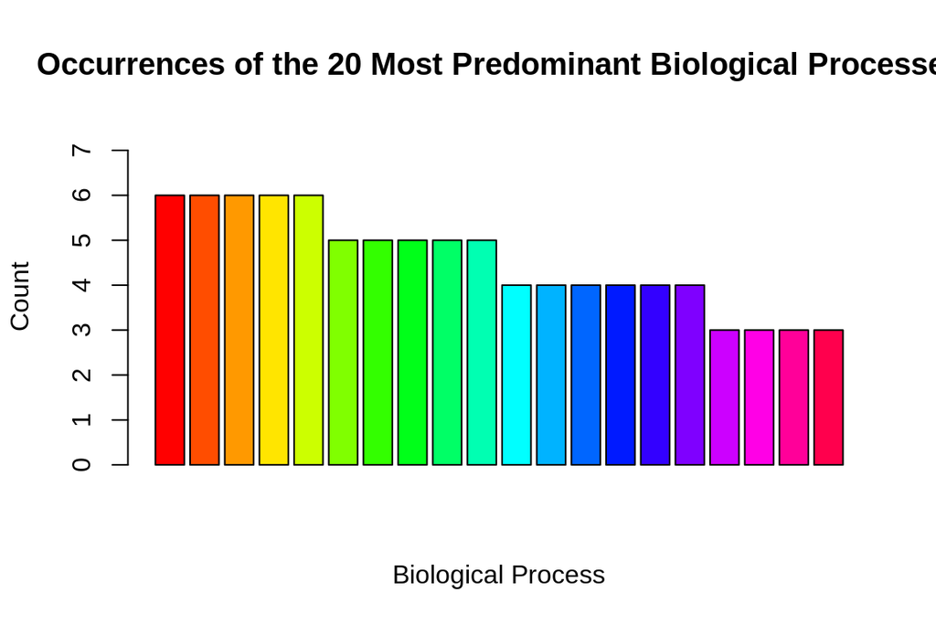

```r
data <- read.csv("blast_annot_go.tab", sep = '\t')

# Rename the `Gene.Ontology..biological.process.` column to `Biological_Process`
colnames(data)[colnames(data) == "Gene.Ontology..biological.process."] <- "Biological_Process"

# Separate the `Biological_Process` column into individual biological processes
data_separated <- unlist(strsplit(data$Biological_Process, split = ";"))

# Trim whitespace from the biological processes
data_separated <- gsub("^\\s+|\\s+$", "", data_separated)

# Count the occurrences of each biological process
process_counts <- table(data_separated)
process_counts <- data.frame(Biological_Process = names(process_counts), Count = as.integer(process_counts))
process_counts <- process_counts[order(-process_counts$Count), ]

# Select the 20 most predominant biological processes
top_20_processes <- process_counts[1:20, ]

# Create a color palette for the bars
bar_colors <- rainbow(nrow(top_20_processes))

# Create a staggered vertical bar plot with different colors for each bar
barplot(top_20_processes$Count, names.arg = rep("", nrow(top_20_processes)), col = bar_colors,
        ylim = c(0, max(top_20_processes$Count) * 1.25),
        main = "Occurrences of the 20 Most Predominant Biological Processes", xlab = "Biological Process", ylab = "Count")
```

```r
# Create a separate plot for the legend
png("output/GOlegend.png", width = 800, height = 600)
par(mar = c(0, 0, 0, 0))
plot.new()
legend("center", legend = top_20_processes$Biological_Process, fill = bar_colors, cex = 1, title = "Biological Processes")
dev.off()
```

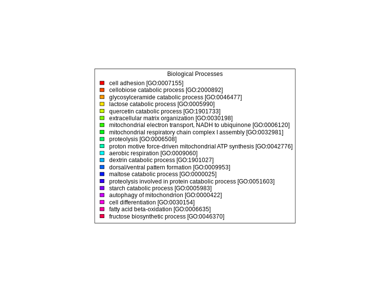

```r
knitr::include_graphics("output/GOlegend.png")
```